# Rational Choice Models

# Rational Choice Models

## Collective action and free riding

- Rational choice model suggests people will typically prefer to free ride on the benefits of collective action.
- Unlike models that emphasize mostly individual-characteristics, rational choice models draw attention to:
  - Factors that impact the probability of success
  - Factors that influence the “costs” or benefits of association.

## What does it mean to be rational?

- Utility maximization: given two options, a rational actor will choose the one that maximizes their expected utility.
  - Utility itself is not defined. It could be money, power or even just good vibes.
- **Completeness:** I can compare any pair of options and tell you whether one is better, worse, or equal.
- **Transitivity:** If A > B and B > C then A > C. In other words, I can consistently rank all of my options from best to worst.
- Classical models typically assume perfect information: I know everything necessary to quantify the utility of a decision, but this is often relaxed.

## What does it mean to be rational?

- “Utility” is subjective, rationality is about a decision making process, not an assessment of the goals themselves.
  - There are rational-choice models of suicide terrorism and rationalist explanations for genocide.

## Expected Utility Formula

A simplified version of an expected utility model for a decision with an uncertain outcome looks like this:

$$EU(A) = U_{pg} \times P(PG|A) - C$$

- $P(PG|A)$ = The probability of “winning” or “success” given that you did action “A”
- $U_{pg}$ = The utility gained from success
- $C$ = The costs of action A
- $EU(A)$ = the expected Utility from action A

## Expected Utility Formula

$$EU(A) = U_{pg} \times P(PG|A) - C$$

The expected utility from *not* doing action A is:

$$EU(\neg A) = U_{pg} \times P(PG|\neg A)$$

$\neg$ = negation symbol. Read as “NOT”

## Expected Utility Formula

What’s the expected utility for playing the lottery?

$$EU(A) = U_{pg} \times P(PG|A) - C$$

Payoff for playing:

- $P(PG|A)$ = $1 \text{ in } 292,201,338$ or $0.000000003422298$
- $U_{pg}$ = Initial projected jackpot: $\$20,000,000$
- $C$ = The costs of a ticket: $\$2$
- $EU(A)$ = $(0.000000003422298\times \$20,000,000) - \$ 2 = -\$1.93$

## Expected Utility Formula

What’s the expected utility for NOT playing the lottery?

$$EU(\neg A) = U_{pg} \times P(PG|\neg A)$$

Payoff for NOT playing:

- $P(PG|\neg A)$ = $0$
- $U_{pg}$ = Initial projected jackpot: $\$20,000,000$
- $C$ = The costs of not buying a ticket: $0$
- $EU(\neg A)$ = $(0\times \$20,000,000) - \$ 0 = \$0$

## Expected Utility Formula

$$EU(A) = U_{pg} \times P(PG|A) - C$$

$$EU(\neg A) = U_{pg} \times P(PG|\neg A)$$

When does playing the lottery become rational? In other words, when does $EU(\neg A) < EU(A)$?

## Expected Utility

How do intangible goods like “equal rights” or policies like “social welfare” differ from playing a lottery?

$$EU(A) = U_{pg} \times P(PG|A) - C$$

$$EU(\neg A) = U_{pg} \times P(PG|\neg A)$$

$P(PG|\neg A)$ is always zero for the lottery, but what if I can have some of the jackpot without paying?

If $P(PG|\neg A)$ is close to $P(PG|A)$ then costs will almost always exceed benefits, even when the benefit is huge.

## Public and private goods

Many theories of politics assume people with shared interests will form interest groups, but rational choice models suggest this is actually rare for certain types of goods and certain types of group.

[output not shown]

## Public and private goods

The basic problem:

- Contentious actors usually pursue public or club goods, so there’s always incentive to free ride
- Moreover, contentious actors face high costs: being on the losing side of a rebellion has a huge downside.
- The expectation that others will free-ride makes participation even less attractive (because $P(PG)$ depends partly on the number of people who choose to join)

## Collective Action and Revolution

Consider a payoff structure like this:

|  | Actor B: Join the rebellion | Actor B: Stay home |
| --- | --- | --- |
| **Actor A: Join the rebellion** | Revolution: we both get what we want but we split the costs of joining | Revolution: (but Actor B avoids all costs) |
| **Actor A: Stay home** | Revolution (but actor A avoids all costs) | Mutual defection: actor A and B get nothing |

Where do rational actors end up?

## Collective Action and Revolution

Consider a payoff structure like this:

|  | **Cooperate** | **Defect** |
| --- | --- | --- |
| **Cooperate** | 3, 3 | 1, 4 |
| **Defect** | 4, 1 | 2, 2 |

Where do rational actors end up?

## Collective Action and Revolution

|  | **Cooperate** | **Defect** |
| --- | --- | --- |
| **Cooperate** | 3, 3 | 1, 4 |
| **Defect** | 4, 1 | 2, 2 |

The **equilibrium** outcome is not **Pareto optimal**

## Solutions to the CA problem

The “supply” of collective action doesn’t meet the “demand”, but large-scale collective action still happens. Why?

- We’ll explore a few, but the list here is by no means exhaustive!

### Monopoly or Oligopoly

- If the benefit is large, the number of recipients is small, and the contribution to the $P(PG|A)$ is significant, then even private actors will provide non-excludable goods (industry lobbying groups are a class case)
- If a firm lacks competitors, they might not care about “non-excludability” (company towns, “Fordlandia”, Disneyworld)

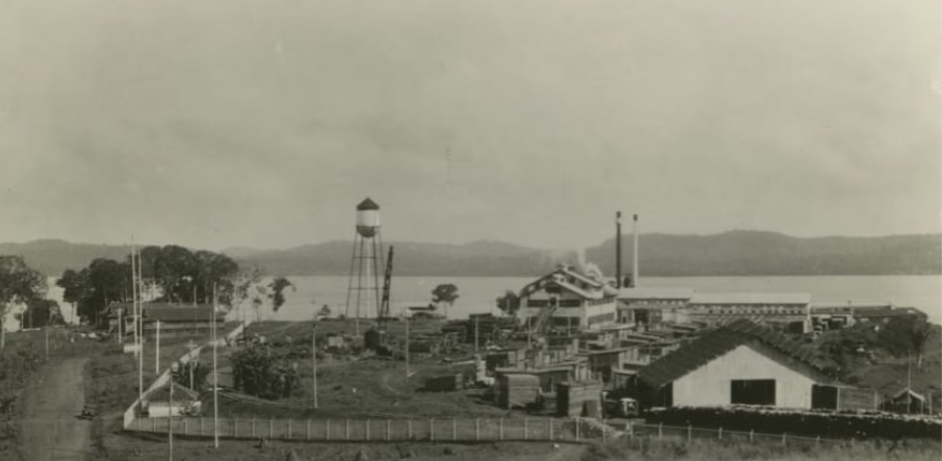

### Selective incentives

Leaders can add a selective ($S$) incentive that you only receive by joining.

$$EU(A) = U_{pg} \times P(PG|A) - C + S$$

$$EU(\neg A) = U_{pg} \times P(PG|\neg A)$$

This is most likely to be effective when $C$ is small.

### Selective Incentives

- Many interest groups (especially large ones that engage in conventional lobbying) provide selective incentives like discounts and coupons.
- However, the costs of participation also need to be quite low.

[figure not shown]

### Selective Incentives

- Higher risk collective actors may require higher rewards to recruit, and this inevitably requires access to resources.
- Resource-poor groups might rely mostly on intangible incentives and punishments (ideology, social sanction/reward, “fun”)

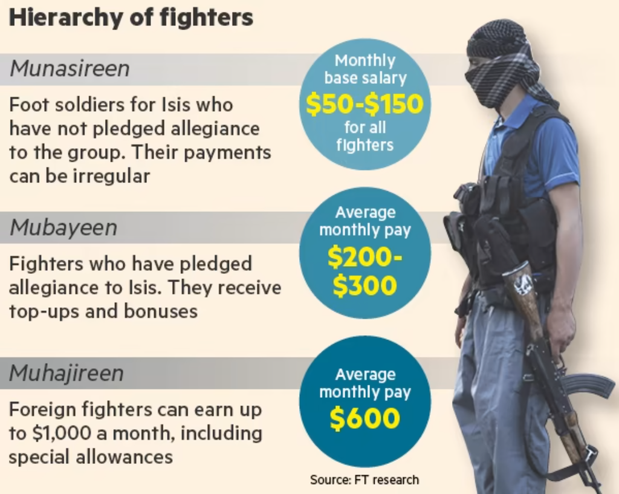

### Random repression

- If potential participants expect punishment regardless of participation, then there are few or no relative costs for joining a rebellion.

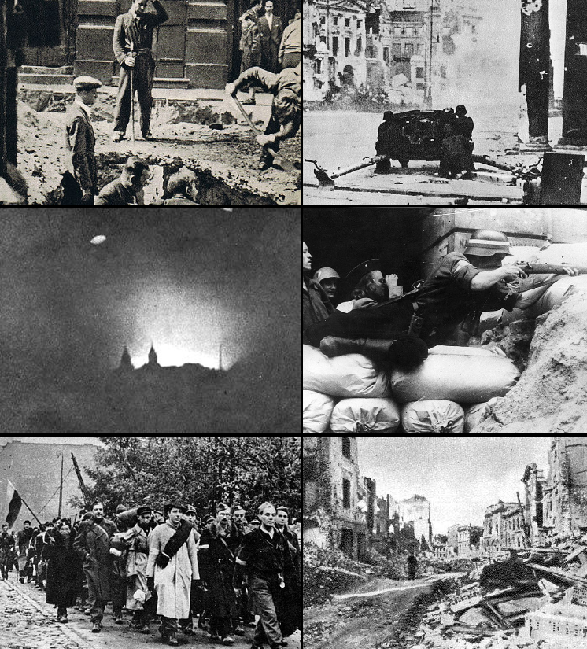

images from the Warsaw Uprising in Nazi occupied Poland

### Assurance

- Monitoring/Sanctions can reassure actors that others won’t defect AND take away the incentive to do the same.
- However, this presents its own problems: monitoring and sanctions are themselves a kind of public good.

### Some key considerations

- Are movements seeking “club goods” or “public goods”?
- Are groups large or small?
- Are these “one-off” games or iterated games?
- Given that protest *does* happen, what are the conditions that make it possible? What factors matter in this perspective that are less important for a “strain/breakdown” perspective?